# LCL Fiber-seq: top 10 heterozygous AS-FIRE regions

Crystal Shan

2026-09-15

````r
knit_report <- function(inputFile, encoding = "UTF-8") {
  lines <- readLines(inputFile, warn = FALSE)
  start <- which(trimws(lines) == "```{r lcl-output-loader}")
  stopifnot(length(start) == 1L)
  end <- which(seq_along(lines) > start & trimws(lines) == "```")[1L]
  stopifnot(!is.na(end), end > start + 1L)
  eval(parse(text = lines[seq.int(start + 1L, end - 1L)]))
  source_lcl_output_config(inputFile)
  source("/project/spott/cshan/fiber-seq/code/clustering_methods/Leiden_Manhattan/leiden_manhattan_functions.r", local = TRUE)
  source("/project/spott/cshan/fiber-seq/code/haplotype_phasing/LCL_phasing.r", local = TRUE)
  source("/project/spott/cshan/fiber-seq/code/clustering_methods/Leiden_Manhattan/leiden_manhattan_plots.r", local = TRUE)
  render_report(inputFile, encoding = encoding)
}
````

```r
knit_report("/project/spott/cshan/fiber-seq/code/clustering_methods/Leiden_Manhattan/leiden_LCL.Rmd")
```

````r
source_lcl_output_config <- function(notebook, envir = parent.frame()) {
  lines <- readLines(notebook, warn = FALSE)
  start <- which(trimws(lines) == "```{r lcl-output-config}")
  if (length(start) != 1L) stop("Expected one LCL output configuration chunk")
  end <- which(seq_along(lines) > start & trimws(lines) == "```")[1L]
  if (is.na(end) || end <= start + 1L) stop("Missing LCL output configuration code")
  eval(parse(text = lines[seq.int(start + 1L, end - 1L)]), envir = envir)
  invisible(NULL)
}
````

```r
LCL_OUTPUT_ROOT <- "/project/spott/cshan/fiber-seq/LCL_project/Leiden_manhattan"
LCL_TOP10_ROOT <- Sys.getenv("LCL_REPORT_ROOT", unset = LCL_OUTPUT_ROOT)
lcl_output_path <- function(path) {
  if (any(strsplit(path, "/", fixed = TRUE)[[1]] %in% c(".", "..")))
    stop("Output path must not contain dot components")
  root <- normalizePath(LCL_OUTPUT_ROOT, mustWork = TRUE)
  ancestor <- path
  suffix <- character()
  while (!file.exists(ancestor)) {
    suffix <- c(basename(ancestor), suffix)
    parent <- dirname(ancestor)
    if (identical(parent, ancestor)) stop("Cannot resolve output path")
    ancestor <- parent
  }
  resolved <- do.call(file.path, as.list(c(normalizePath(ancestor), suffix)))
  if (!(identical(resolved, root) || startsWith(resolved, paste0(root, "/"))))
    stop("Output must be inside ", root, ": ", path)
  resolved
}
```

# Select the top 10 AS-FIRE regions

*Definition of AS-FIRE and how it is selected:*

1. AS-FIRE: whehther a FIRE peak is accessible at different frequencies on reads carrying a SNP’s reference vs alternate allele
2. retains genotypes 0|1 or 1|0, retains reads tagged H1/H2, and pairs peaks with nearby variants using a 2,000-bp distance setting
- Each SNP is associated with a set of contributing samples based on its phase and the phase of the reads
- Different SNPs can therefore have different contributing samples
3. Counts are combined across contributing samples for each SNP–peak pair
- Fisher’s exact test compares reference/alternate alleles against FIRE/non-FIRE observations
4. Significance filters
- combined coverage >= 20 reads
- reference and alternate alleles each have >= 0 reads
- q value < 0.1
- FIRE frequency >= 0.1

AS-FIRE from kevin: - /project/spott/kevinluo/Fiber_seq/results/QTL/fireQTL/AS_fire_freq_results/combined_results/combined_AS_fire_freq_merged_peaks_window2000_firefreq0.1_het_only.rds

| peak_name | rsID | snp_pos | ref | alt | coverage_ref | coverage_alt | fisher_pvalue |
| --- | --- | --- | --- | --- | --- | --- | --- |
| chr1_11161_11494 | rs180734498 | 13302 | C | T | 2 | 3 | 0.5238095 |
| chr1_28837_29482 | rs140337953 | 30923 | G | T | 19 | 25 | 0.6412728 |
| chr1_88661_88783 | rs146836579 | 87647 | T | C | 15 | 5 | 0.6286665 |
| chr1_88661_88783 | rs1524602 | 87190 | G | A | 15 | 5 | 0.6286665 |
| chr1_88661_88783 | rs59529791 | 88136 | G | A | 15 | 5 | 0.6286665 |

*Selection of top 10 regions:* Only biallelic A/C/G/T SNPs with a valid rsID and a complete 2 kb reference window are eligible. Each region is defined by the lead SNP’s position and the FIRE peak, in this case, it is the SNP with the smallest Fisher p-value within the peak

- allele label: each phased read is assigned to H1 or H2 based on the focal SNP’s phased genotype in the sample
- lowest p-value: the SNP with the lowest Fisher p-value within the peak is selected as the focal SNP for that region
- before clustering, homozygous and unphased reads are removed

example block table: - `/project/spott/1_Shared_projects/LCL_Fiber_seq/preprocess_final_merged_samples/AL10_bc2178_19130/blocks.tsv`

| source_block_index | sample_name | phase_block_id | chrom | start | end | num_variants |
| --- | --- | --- | --- | --- | --- | --- |
| 1 | NA19130 | 52238 | chr1 | 52238 | 103905 | 16 |
| 1 | NA19130 | 126108 | chr1 | 126108 | 135032 | 2 |
| 4 | NA19130 | 591460 | chr1 | 591460 | 599165 | 5 |
| 5 | NA19130 | 638771 | chr1 | 638771 | 638771 | 1 |
| 5 | NA19130 | 665098 | chr1 | 665098 | 683083 | 3 |
| 6 | NA19130 | 779825 | chr1 | 779825 | 1190918 | 437 |
| 8 | NA19130 | 1285767 | chr1 | 1285767 | 1290261 | 2 |
| 9 | NA19130 | 1339884 | chr1 | 1339884 | 1339911 | 2 |
| 12 | NA19130 | 1427454 | chr1 | 1427454 | 1427474 | 3 |
| 14 | NA19130 | 1457071 | chr1 | 1457071 | 1457071 | 1 |
| 15 | NA19130 | 1483249 | chr1 | 1483249 | 1492007 | 3 |
| 16 | NA19130 | 1514366 | chr1 | 1514366 | 1516323 | 2 |
| 17 | NA19130 | 1543702 | chr1 | 1543702 | 1922424 | 259 |

example read level haplotype file: - `/project/spott/1_Shared_projects/LCL_Fiber_seq/preprocess_final_merged_samples/AL10_bc2178_19130/read-level-phasing.tsv` - haplotag 1 = first allele in GT

| source_block_index | sample_name | chrom | phase_block_id | read_name | haplotag |
| --- | --- | --- | --- | --- | --- |
| 4 | NA19130 | chr1 | 591460 | m84241_250311_201728_s2/81201882/ccs | 1 |
| 4 | NA19130 | chr1 | 591460 | m84241_250311_201728_s2/219218451/ccs | 1 |
| 4 | NA19130 | chr1 | 591460 | m84241_250311_201728_s2/65275399/ccs | 2 |
| 4 | NA19130 | chr1 | 591460 | m84241_250311_201728_s2/7869529/ccs | 1 |
| 4 | NA19130 | chr1 | 591460 | m84241_250311_201728_s2/56759899/ccs | 1 |

example vcf file: - `/project/spott/1_Shared_projects/LCL_Fiber_seq/preprocess_final_merged_samples/AL10_bc2178_19130/AL10_bc2178_19130.5mC.6mA.aligned.phased.vcf.gz` - GT = 0|1 means HP1 carries reference allele and HP2 carries alternate allele - PS = a cluster of phased genotypes that belong to the same local chromosome block - GT:PS = 0|1:100 with A and T, and GT:PS = 0|1:100 with C and G means haplotype A reads A-C and haplotype B reads T-G

The block file and vcf file are used to determine the phased genotype of each read at the focal SNP - they are matched based on the sample name, chr, and phase_block_id - groups of variants whose alleles have been assgned to the same haplotype (H1 or H2) based on the phased genotype of the sample

example RDS file produced by cache_lcl_haplotags - finds the block containing the focal SNP, then matches its ID to the VCF and read haplotags to determine each read’s allele - `/project/spott/cshan/fiber-seq/LCL_project/Leiden_manhattan/phase_summary/AL10_bc2178_19130_haplotags.rds`: a list contain the blocks file and the tags file with haplotype label for each read

```r
asfire_file <- "/project/spott/kevinluo/Fiber_seq/results/QTL/fireQTL/AS_fire_freq_results/combined_results/combined_AS_fire_freq_merged_peaks_window2000_firefreq0.1_het_only.rds"
sample_csv <- "/project/spott/1_Shared_projects/LCL_Fiber_seq/Data/LCL_sample_metatable_merged_samples_31samples.csv"
sample_table <- read.csv(sample_csv, stringsAsFactors = FALSE)
stopifnot(!anyDuplicated(sample_table$sample_name),
          !anyDuplicated(sub("_.*$", "", sample_table$sample_name)))
phasing_root <- "/project/spott/1_Shared_projects/LCL_Fiber_seq/preprocess_final_merged_samples"
signature_file <- file.path(output_dir, "summary tables", "selection_signature.rds")
if (file.exists(signature_file)) {
  signature <- readRDS(signature_file)
  regions <- signature$regions
  sample_table <- signature$sample_table
} else {
  asfire_results <- readRDS(asfire_file)
  regions <- select_lcl_top_asfire_regions(asfire_results, top_n = 10L, width_bp = 2000L)
  rm(asfire_results)
}
knitr::kable(regions[, c("rank", "region_id", "peak_name", "focal_snp", "focal_pos",
  "fisher_pvalue", "fisher_qvalue", "coverage", "coverage_ref", "coverage_alt",
  "n_listed_samples", "analysis_start", "analysis_end", "overlapping_selected_windows",
  "overlapping_selected_peaks", "nearest_selected_snp_distance_bp", "same_focal_snp_as_another_peak")])
```

| rank | region_id | peak_name | focal_snp | focal_pos | fisher_pvalue | fisher_qvalue | coverage | coverage_ref | coverage_alt | n_listed_samples | analysis_start | analysis_end | overlapping_selected_windows | overlapping_selected_peaks | nearest_selected_snp_distance_bp | same_focal_snp_as_another_peak |
| --- | --- | --- | --- | --- | --- | --- | --- | --- | --- | --- | --- | --- | --- | --- | --- | --- |
| 1 | rank01_rs12470189_chr2_119290945_119291178 | chr2_119290945_119291178 | rs12470189 | 119291056 | 0 | 0 | 308 | 135 | 173 | 15 | 119290056 | 119292055 |  |  | 54608152 | FALSE |
| 2 | rank02_rs2236610_chr21_34688259_34688428 | chr21_34688259_34688428 | rs2236610 | 34688369 | 0 | 0 | 328 | 157 | 171 | 14 | 34687369 | 34689368 |  |  | NA | FALSE |
| 3 | rank03_rs4061832_chr3_98334086_98334294 | chr3_98334086_98334294 | rs4061832 | 98334189 | 0 | 0 | 360 | 192 | 168 | 12 | 98333189 | 98335188 |  |  | NA | FALSE |
| 4 | rank04_rs170738_chr5_55421001_55421578 | chr5_55421001_55421578 | rs170738 | 55421097 | 0 | 0 | 378 | 190 | 188 | 14 | 55420097 | 55422096 |  |  | NA | FALSE |
| 5 | rank05_rs1457288_chr8_109521517_109521780 | chr8_109521517_109521780 | rs1457288 | 109522546 | 0 | 0 | 336 | 179 | 157 | 16 | 109521546 | 109523545 |  |  | NA | FALSE |
| 6 | rank06_rs10826861_chr10_30751957_30752154 | chr10_30751957_30752154 | rs10826861 | 30752051 | 0 | 0 | 311 | 150 | 161 | 15 | 30751051 | 30753050 |  |  | NA | FALSE |
| 7 | rank07_rs1999686_chr9_31146879_31147088 | chr9_31146879_31147088 | rs1999686 | 31146953 | 0 | 0 | 419 | 216 | 203 | 13 | 31145953 | 31147952 |  |  | NA | FALSE |
| 8 | rank08_rs12666349_chr7_31688407_31688773 | chr7_31688407_31688773 | rs12666349 | 31688566 | 0 | 0 | 338 | 169 | 169 | 11 | 31687566 | 31689565 |  |  | NA | FALSE |
| 9 | rank09_rs17306827_chr2_173899075_173899320 | chr2_173899075_173899320 | rs17306827 | 173899208 | 0 | 0 | 409 | 201 | 208 | 15 | 173898208 | 173900207 |  |  | 54608152 | FALSE |
| 10 | rank10_rs2210798_chr6_8481830_8482016 | chr6_8481830_8482016 | rs2210798 | 8481289 | 0 | 0 | 361 | 185 | 176 | 13 | 8480289 | 8482288 |  |  | NA | FALSE |

# Main results and haplotype examples

```r
if (params$regenerate_plots) {
  if (file.exists(file.path(output_dir, "summary tables", "fiberseq_result_paths.rds"))) {
    result_paths <- refresh_saved_plots(output_dir)
  } else {
    result_paths <- run_fiberseq_report(regions, asfire_file, sample_table, phasing_root,
      output_dir = output_dir)
  }
} else {
  result_paths <- readRDS(file.path(output_dir, "summary tables", "fiberseq_result_paths.rds"))
}
stopifnot(all(regions$region_id %in% names(result_paths)))
result_paths <- result_paths[regions$region_id]
main_paths <- readRDS(file.path(output_dir, "summary tables", "result_paths.rds"))
knitr::kable(data.table::fread(file.path(output_dir, "summary tables", "run_summary.tsv")))
```

| region_id | rank | peak_name | focal_snp | fisher_pvalue | fisher_qvalue | asfire_coverage | asfire_coverage_ref | asfire_coverage_alt | n_listed_samples | n_retained_samples | n_full_span_reads | n_reads | n_excluded_reads | n_clusters | n_alleles |
| --- | --- | --- | --- | --- | --- | --- | --- | --- | --- | --- | --- | --- | --- | --- | --- |
| rank01_rs12470189_chr2_119290945_119291178 | 1 | chr2_119290945_119291178 | rs12470189 | 0 | 0 | 308 | 135 | 173 | 15 | 15 | 255 | 255 | 0 | 2 | 2 |
| rank02_rs2236610_chr21_34688259_34688428 | 2 | chr21_34688259_34688428 | rs2236610 | 0 | 0 | 328 | 157 | 171 | 14 | 14 | 273 | 272 | 1 | 4 | 2 |
| rank03_rs4061832_chr3_98334086_98334294 | 3 | chr3_98334086_98334294 | rs4061832 | 0 | 0 | 360 | 192 | 168 | 12 | 12 | 314 | 314 | 0 | 4 | 2 |
| rank04_rs170738_chr5_55421001_55421578 | 4 | chr5_55421001_55421578 | rs170738 | 0 | 0 | 378 | 190 | 188 | 14 | 14 | 323 | 323 | 0 | 4 | 2 |
| rank05_rs1457288_chr8_109521517_109521780 | 5 | chr8_109521517_109521780 | rs1457288 | 0 | 0 | 336 | 179 | 157 | 16 | 16 | 296 | 296 | 0 | 5 | 2 |
| rank06_rs10826861_chr10_30751957_30752154 | 6 | chr10_30751957_30752154 | rs10826861 | 0 | 0 | 311 | 150 | 161 | 15 | 15 | 249 | 249 | 0 | 4 | 2 |
| rank07_rs1999686_chr9_31146879_31147088 | 7 | chr9_31146879_31147088 | rs1999686 | 0 | 0 | 419 | 216 | 203 | 13 | 13 | 359 | 359 | 0 | 4 | 2 |
| rank08_rs12666349_chr7_31688407_31688773 | 8 | chr7_31688407_31688773 | rs12666349 | 0 | 0 | 338 | 169 | 169 | 11 | 11 | 288 | 288 | 0 | 4 | 2 |
| rank09_rs17306827_chr2_173899075_173899320 | 9 | chr2_173899075_173899320 | rs17306827 | 0 | 0 | 409 | 201 | 208 | 15 | 15 | 328 | 328 | 0 | 5 | 2 |
| rank10_rs2210798_chr6_8481830_8482016 | 10 | chr6_8481830_8482016 | rs2210798 | 0 | 0 | 361 | 185 | 176 | 13 | 13 | 319 | 319 | 0 | 3 | 2 |

```r
validation_file <- file.path(output_dir, "summary tables", "plot_reproduction_validation.tsv")
if (!file.exists(validation_file)) validation_file <- file.path(output_dir, "summary tables", "fiberseq_validation.tsv")
knitr::kable(data.table::fread(validation_file))
```

| region_id | n_reads | n_clusters | assignments_unchanged | original_result_md5 | nucleosome_footprints | tf_footprints |
| --- | --- | --- | --- | --- | --- | --- |
| rank01_rs12470189_chr2_119290945_119291178 | 255 | 2 | TRUE | ec44dc50e71e7c0b700d8831ace66415 | 1183 | 659 |
| rank02_rs2236610_chr21_34688259_34688428 | 272 | 4 | TRUE | 07572718fe9d3a8c4ef086a5d8d98ebb | 1264 | 785 |
| rank03_rs4061832_chr3_98334086_98334294 | 314 | 4 | TRUE | 63c2eb53fbc67cef9018878da1c057c4 | 1363 | 939 |
| rank04_rs170738_chr5_55421001_55421578 | 323 | 4 | TRUE | dc58f3bbac094f93bcb35233abdc137c | 1282 | 1199 |
| rank05_rs1457288_chr8_109521517_109521780 | 296 | 5 | TRUE | b1b1592c64372ce34c0387c30e60502f | 1050 | 1097 |
| rank06_rs10826861_chr10_30751957_30752154 | 249 | 4 | TRUE | 024058fa30f1ef735e17b20c3b3beec6 | 1364 | 983 |
| rank07_rs1999686_chr9_31146879_31147088 | 359 | 4 | TRUE | bf1e7ca40e27098b74c1d995ed99f83d | 1126 | 998 |
| rank08_rs12666349_chr7_31688407_31688773 | 288 | 4 | TRUE | 21cce2b5bb4ca8a8c89dadeb4755fc9d | 1214 | 1011 |
| rank09_rs17306827_chr2_173899075_173899320 | 328 | 5 | TRUE | 356dcb267ec9e17a4a38408e43488eed | 1289 | 1766 |
| rank10_rs2210798_chr6_8481830_8482016 | 319 | 3 | TRUE | 0bc26773fc7a653b7159452a16f0f2cb | 1010 | 597 |

# Visualization of results

- Accessibility is the fraction of retained cluster reads with an m6A call at an observed site over all the reads in the cluster
- Nucleosome occupancy is the fraction covered by a 130–160 bp footprint at each base, counting overlapping footprints on a read once

```r
figure_gallery("fiberseq_haplotype_example", "Haplotype overview")
```

## Haplotype overview

### rank01_rs12470189_chr2_119290945_119291178

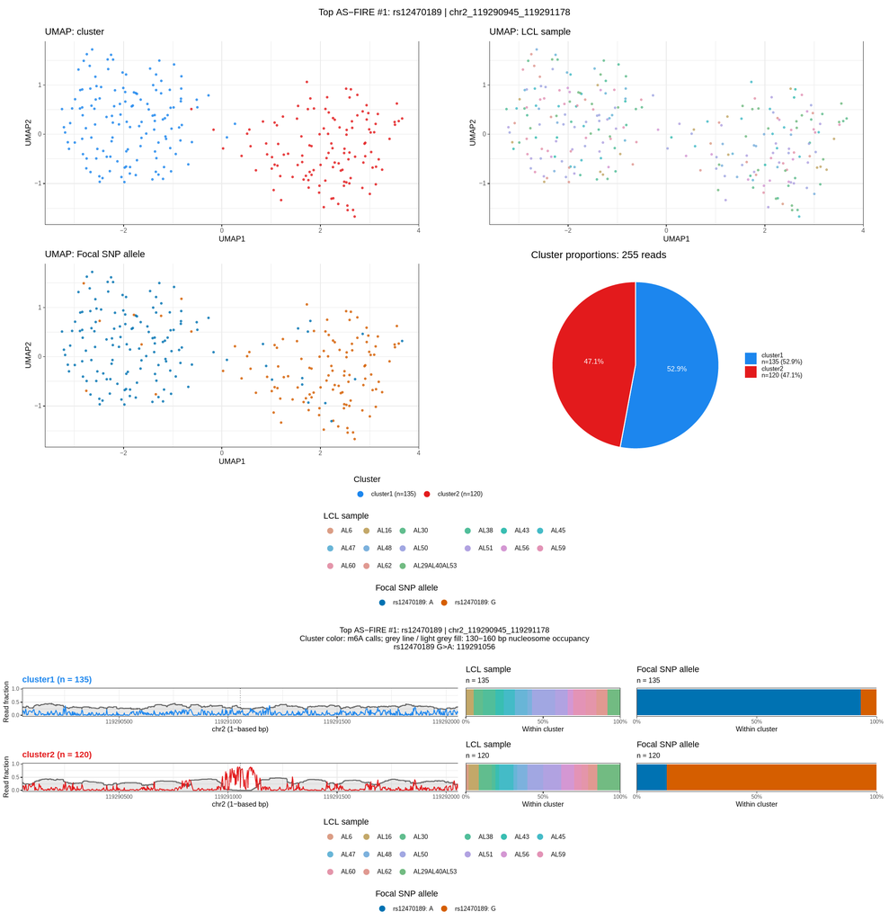

rank01_rs12470189_chr2_119290945_119291178 — Haplotype overview

Download original PDF: fiberseq_haplotype_example

### rank02_rs2236610_chr21_34688259_34688428

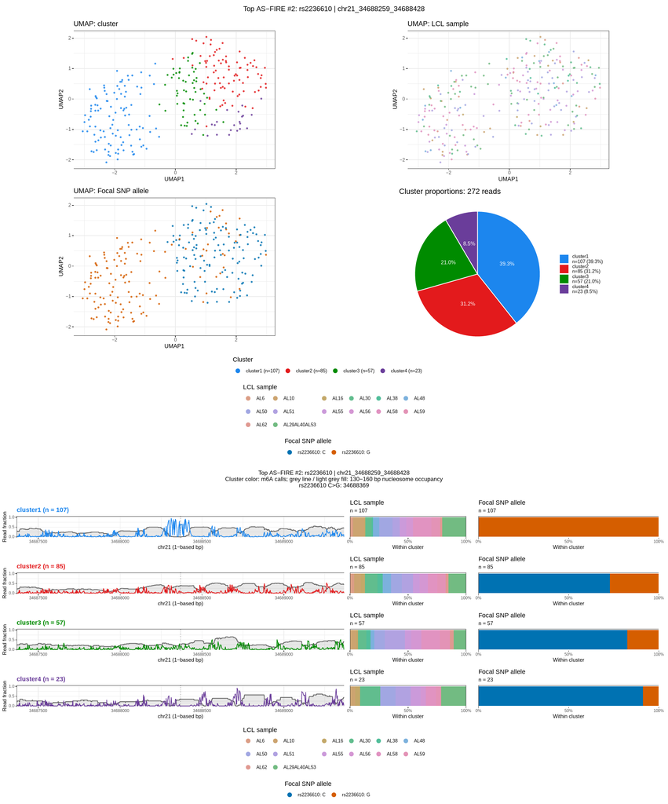

rank02_rs2236610_chr21_34688259_34688428 — Haplotype overview

Download original PDF: fiberseq_haplotype_example

### rank03_rs4061832_chr3_98334086_98334294

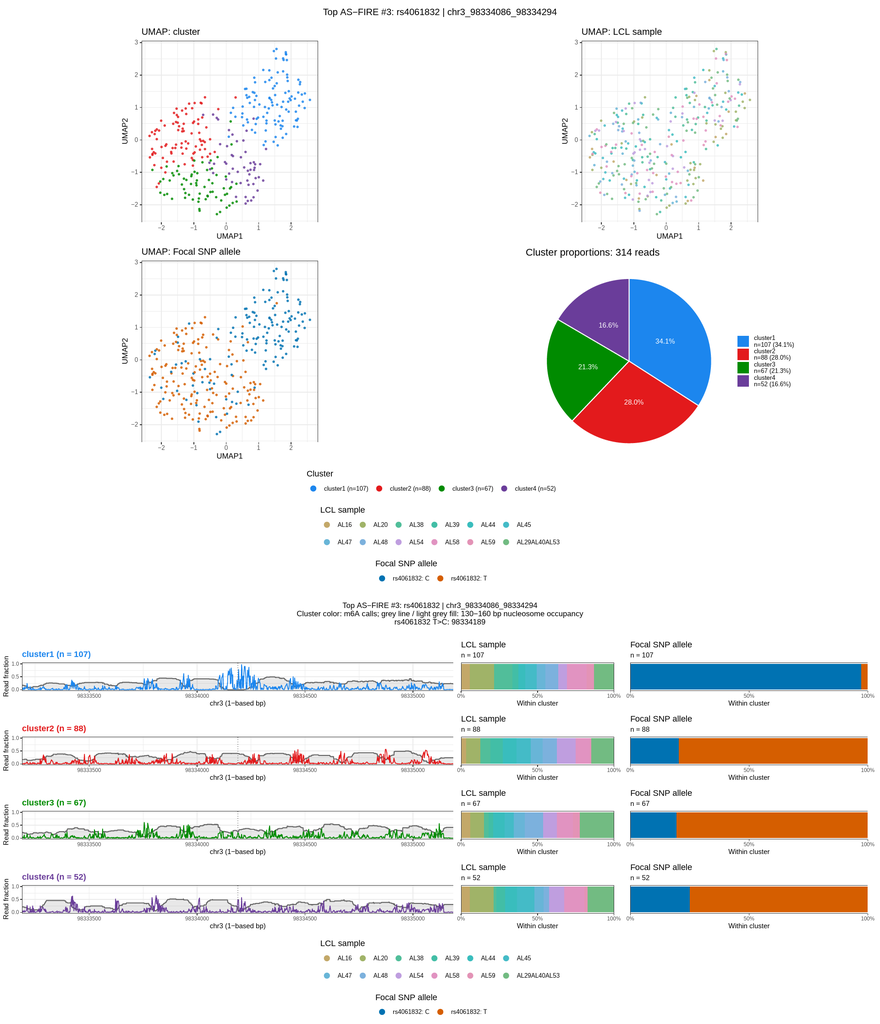

rank03_rs4061832_chr3_98334086_98334294 — Haplotype overview

Download original PDF: fiberseq_haplotype_example

### rank04_rs170738_chr5_55421001_55421578

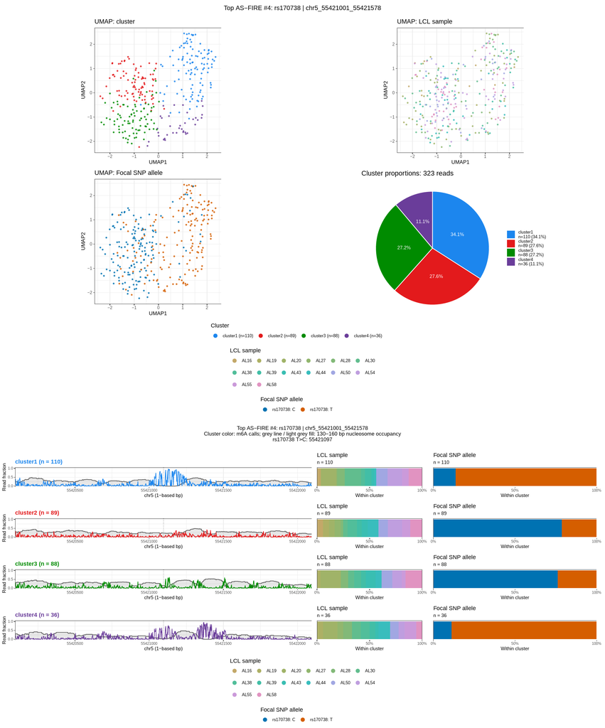

rank04_rs170738_chr5_55421001_55421578 — Haplotype overview

Download original PDF: fiberseq_haplotype_example

### rank05_rs1457288_chr8_109521517_109521780

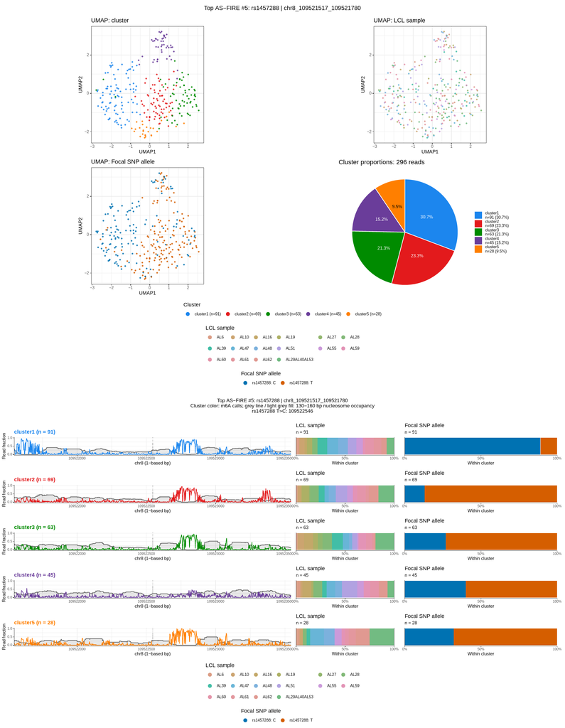

rank05_rs1457288_chr8_109521517_109521780 — Haplotype overview

Download original PDF: fiberseq_haplotype_example

### rank06_rs10826861_chr10_30751957_30752154

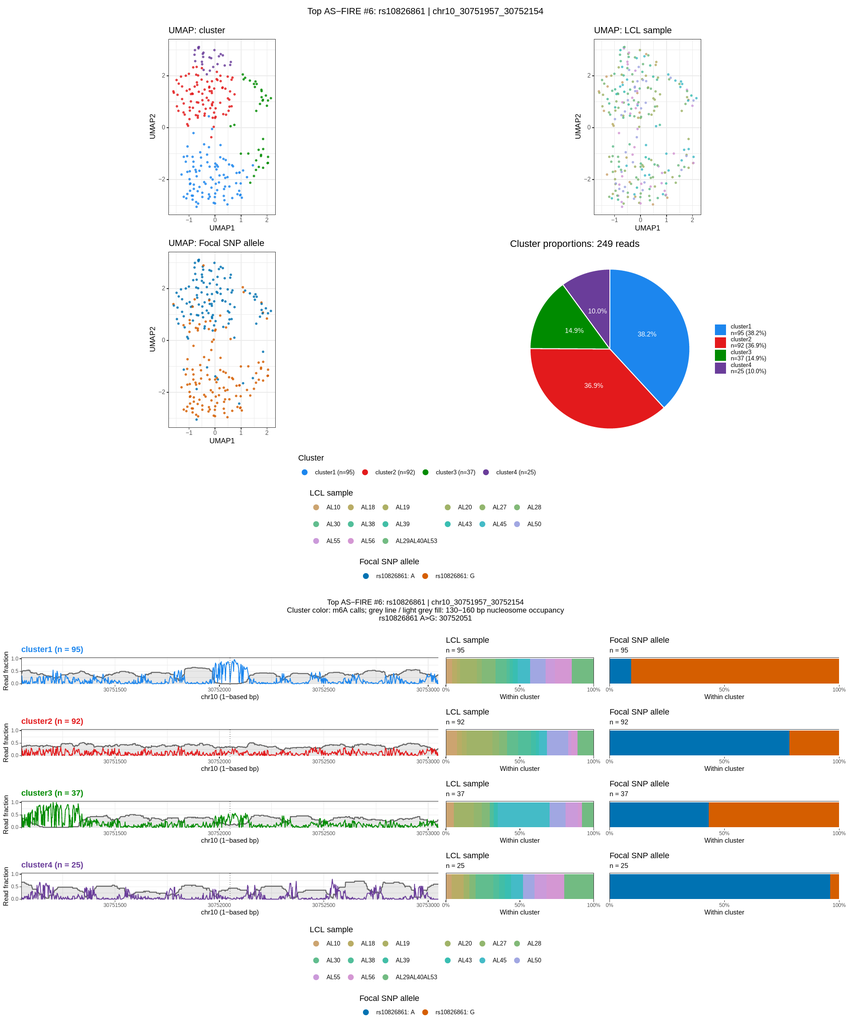

rank06_rs10826861_chr10_30751957_30752154 — Haplotype overview

Download original PDF: fiberseq_haplotype_example

### rank07_rs1999686_chr9_31146879_31147088

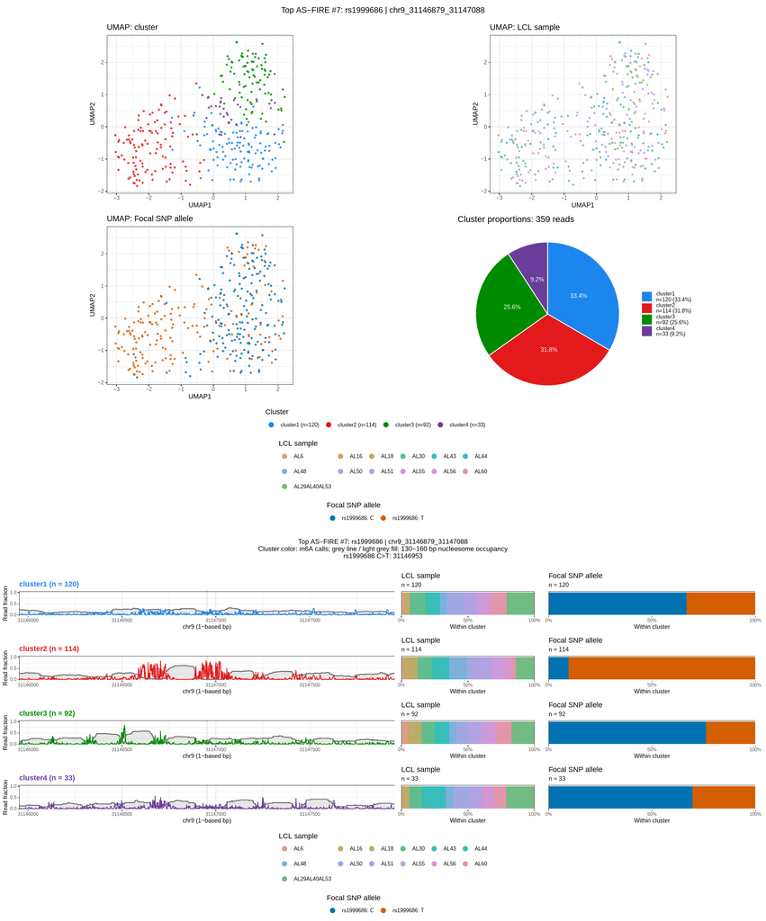

rank07_rs1999686_chr9_31146879_31147088 — Haplotype overview

Download original PDF: fiberseq_haplotype_example

### rank08_rs12666349_chr7_31688407_31688773

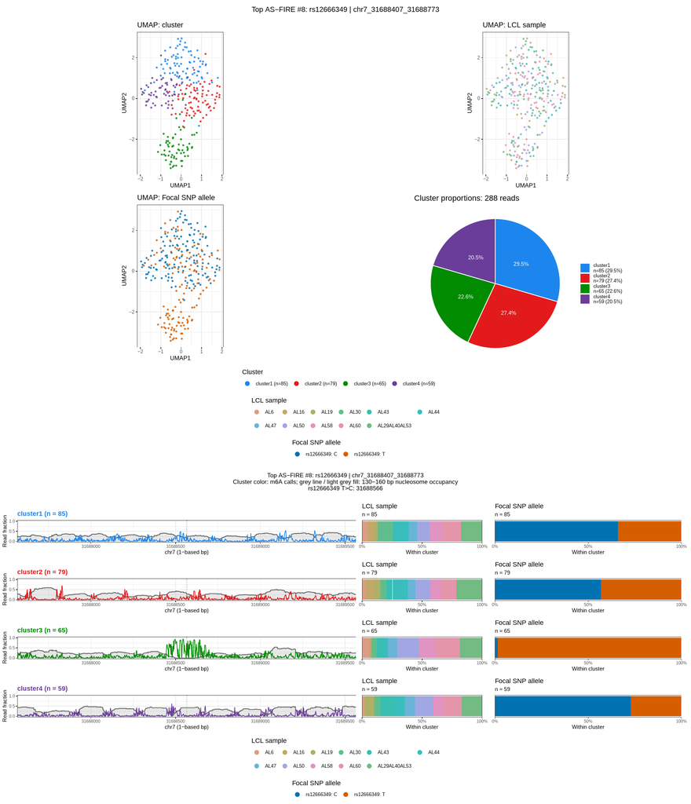

rank08_rs12666349_chr7_31688407_31688773 — Haplotype overview

Download original PDF: fiberseq_haplotype_example

### rank09_rs17306827_chr2_173899075_173899320

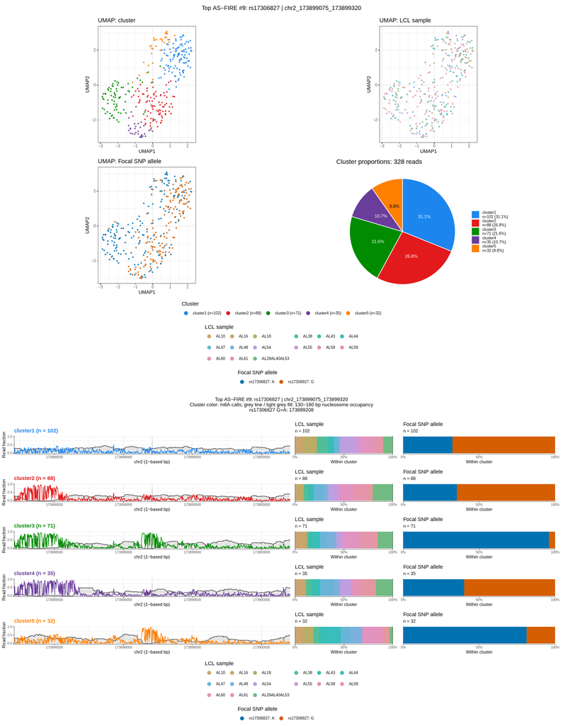

rank09_rs17306827_chr2_173899075_173899320 — Haplotype overview

Download original PDF: fiberseq_haplotype_example

### rank10_rs2210798_chr6_8481830_8482016

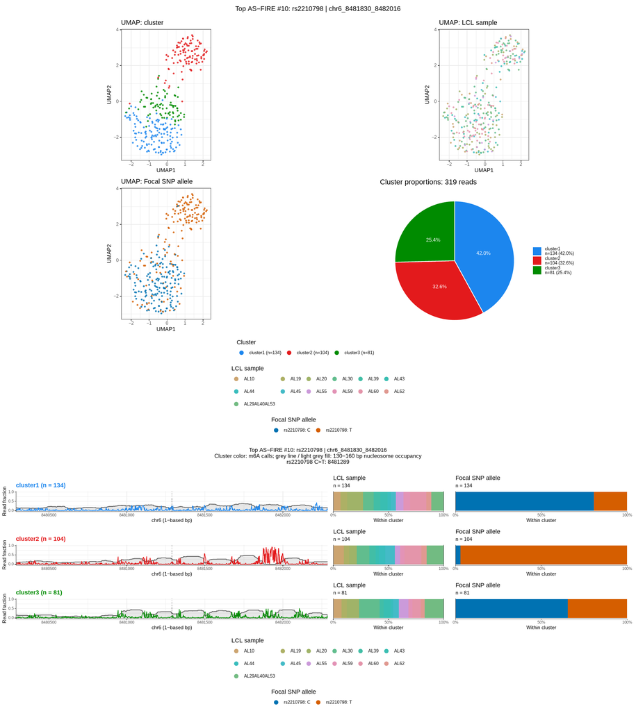

rank10_rs2210798_chr6_8481830_8482016 — Haplotype overview

Download original PDF: fiberseq_haplotype_example

```r
figure_gallery("fig1_read_footprints", "Read-level footprints")
```

## Read-level footprints

### rank01_rs12470189_chr2_119290945_119291178

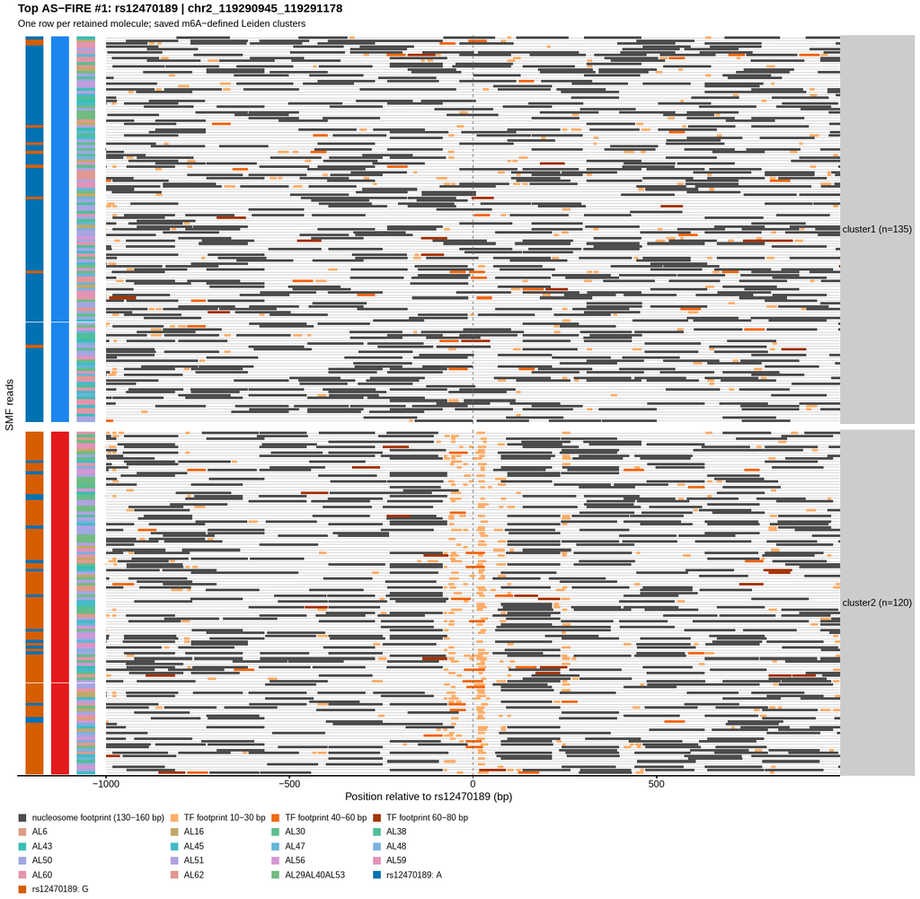

rank01_rs12470189_chr2_119290945_119291178 — Read-level footprints

Download original PDF: fig1_read_footprints

### rank02_rs2236610_chr21_34688259_34688428

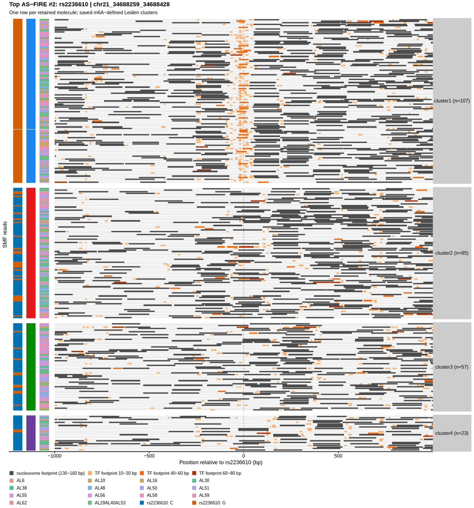

rank02_rs2236610_chr21_34688259_34688428 — Read-level footprints

Download original PDF: fig1_read_footprints

### rank03_rs4061832_chr3_98334086_98334294

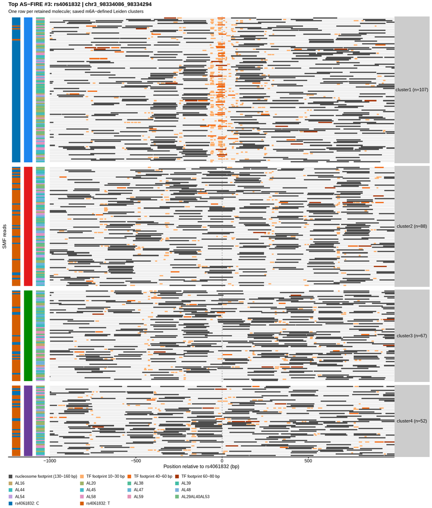

rank03_rs4061832_chr3_98334086_98334294 — Read-level footprints

Download original PDF: fig1_read_footprints

### rank04_rs170738_chr5_55421001_55421578

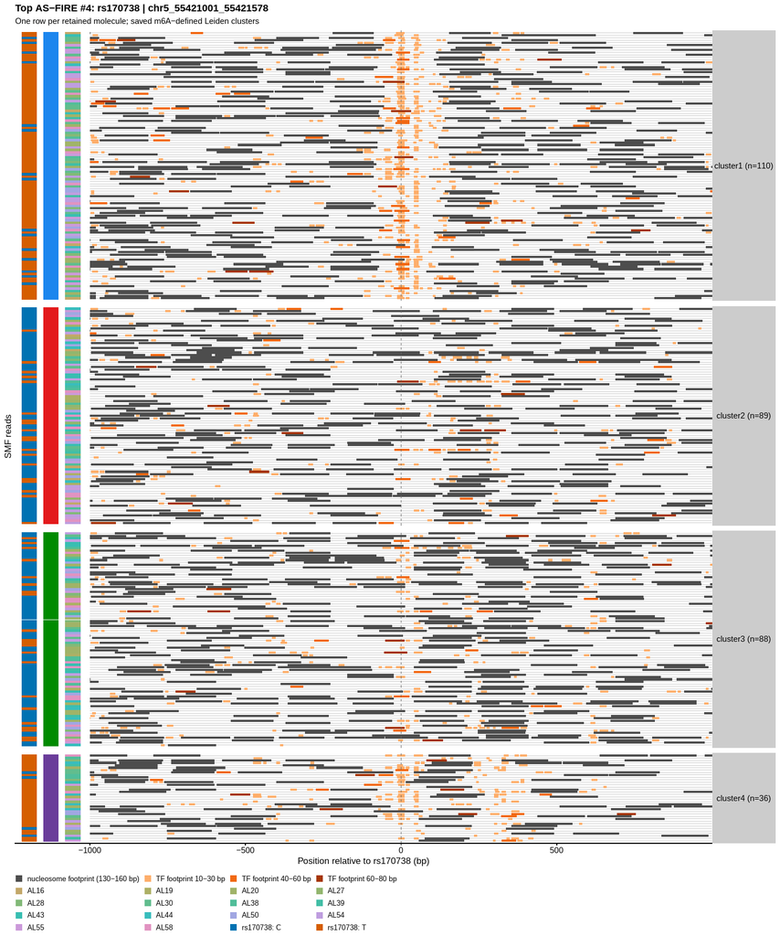

rank04_rs170738_chr5_55421001_55421578 — Read-level footprints

Download original PDF: fig1_read_footprints

### rank05_rs1457288_chr8_109521517_109521780

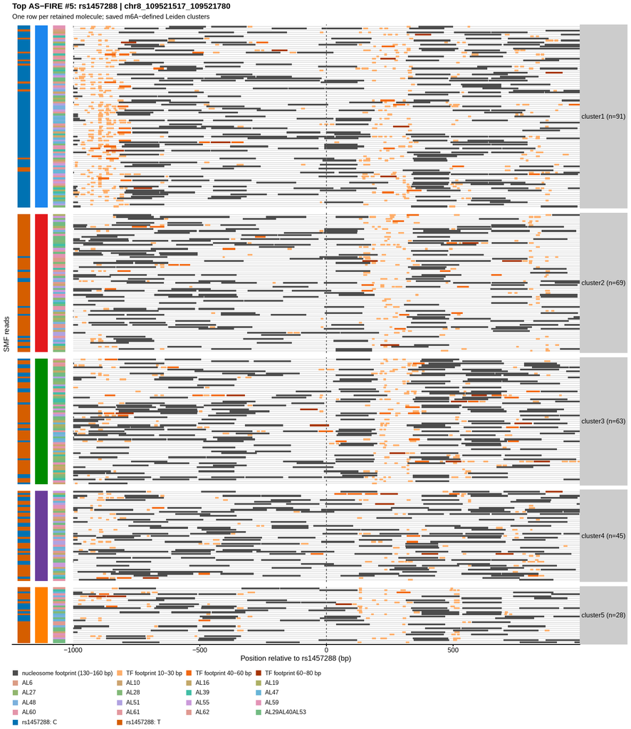

rank05_rs1457288_chr8_109521517_109521780 — Read-level footprints

Download original PDF: fig1_read_footprints

### rank06_rs10826861_chr10_30751957_30752154

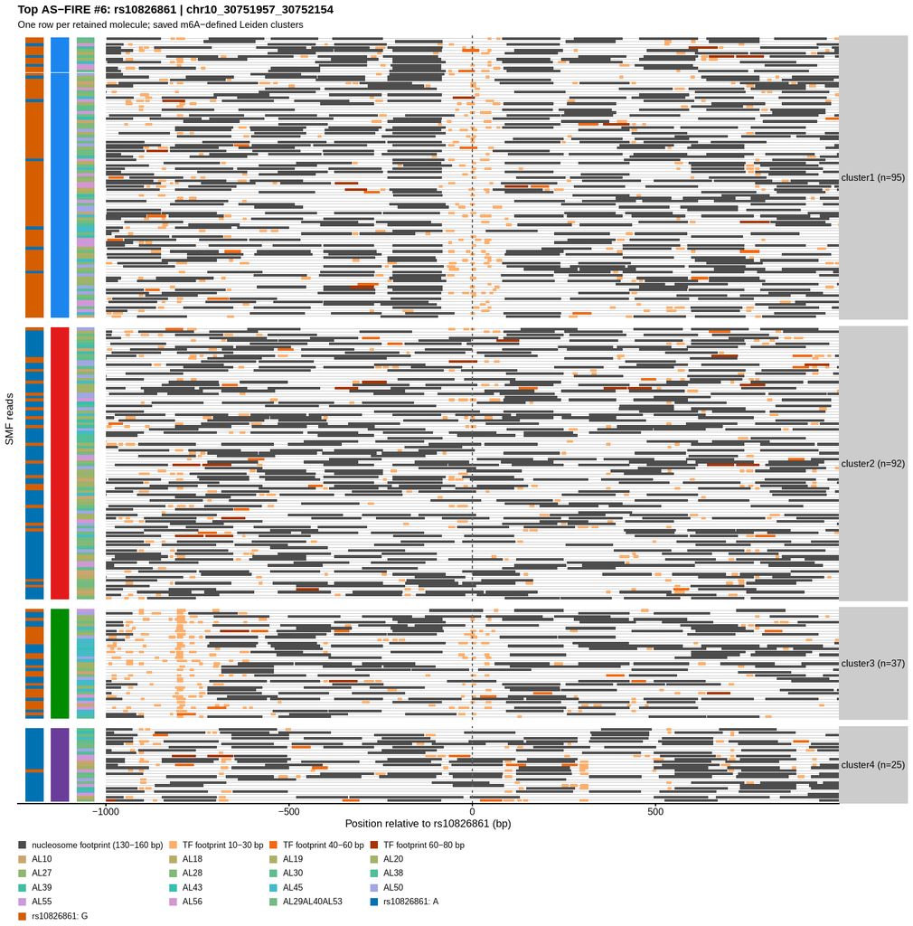

rank06_rs10826861_chr10_30751957_30752154 — Read-level footprints

Download original PDF: fig1_read_footprints

### rank07_rs1999686_chr9_31146879_31147088

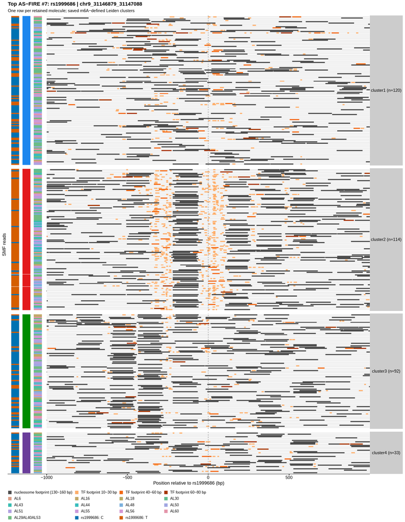

rank07_rs1999686_chr9_31146879_31147088 — Read-level footprints

Download original PDF: fig1_read_footprints

### rank08_rs12666349_chr7_31688407_31688773

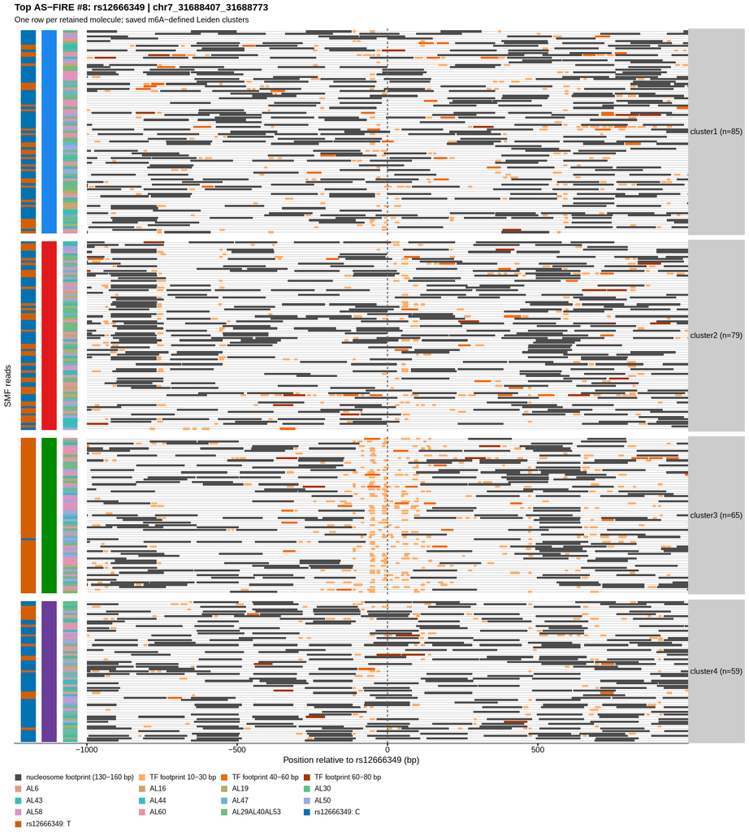

rank08_rs12666349_chr7_31688407_31688773 — Read-level footprints

Download original PDF: fig1_read_footprints

### rank09_rs17306827_chr2_173899075_173899320

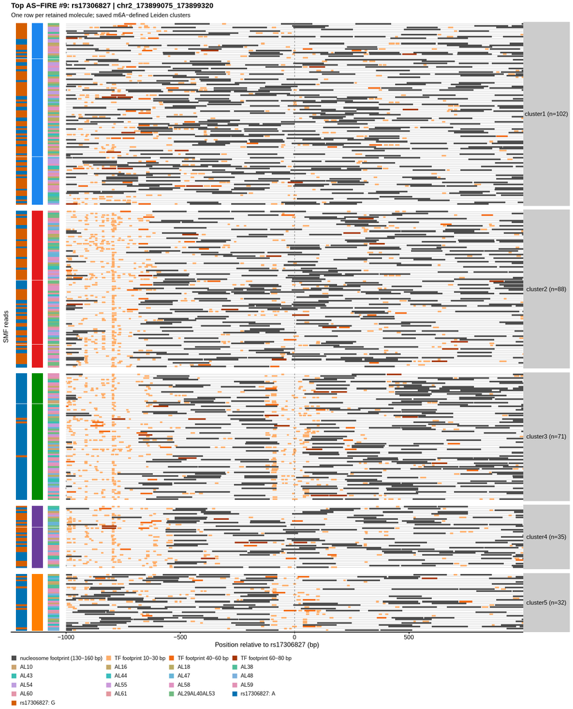

rank09_rs17306827_chr2_173899075_173899320 — Read-level footprints

Download original PDF: fig1_read_footprints

### rank10_rs2210798_chr6_8481830_8482016

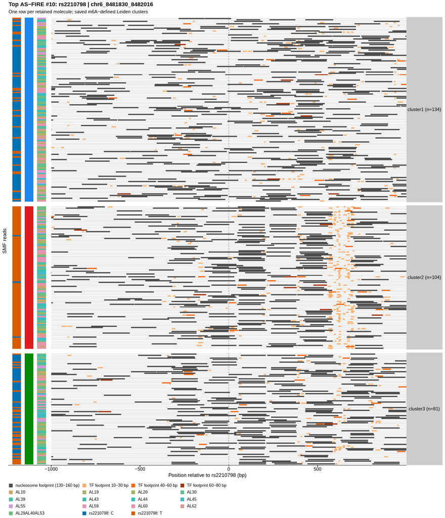

rank10_rs2210798_chr6_8481830_8482016 — Read-level footprints

Download original PDF: fig1_read_footprints

```r
figure_gallery("fig2_occupancy_by_cluster", "Occupancy profiles by cluster")
```

## Occupancy profiles by cluster

### rank01_rs12470189_chr2_119290945_119291178

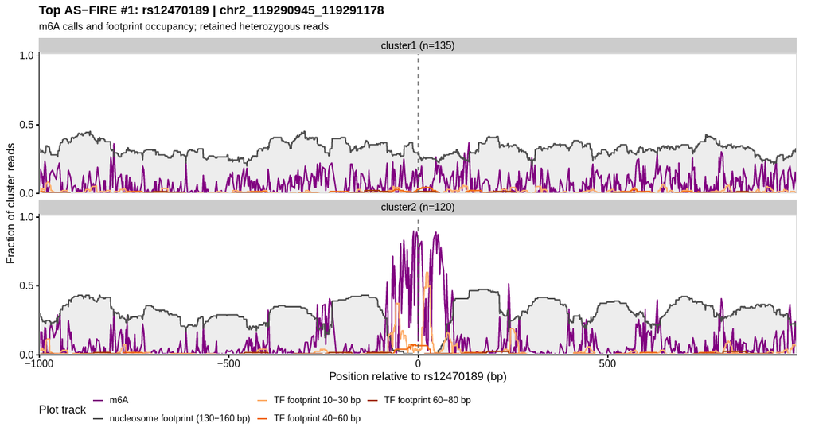

rank01_rs12470189_chr2_119290945_119291178 — Occupancy profiles by cluster

Download original PDF: fig2_occupancy_by_cluster

### rank02_rs2236610_chr21_34688259_34688428

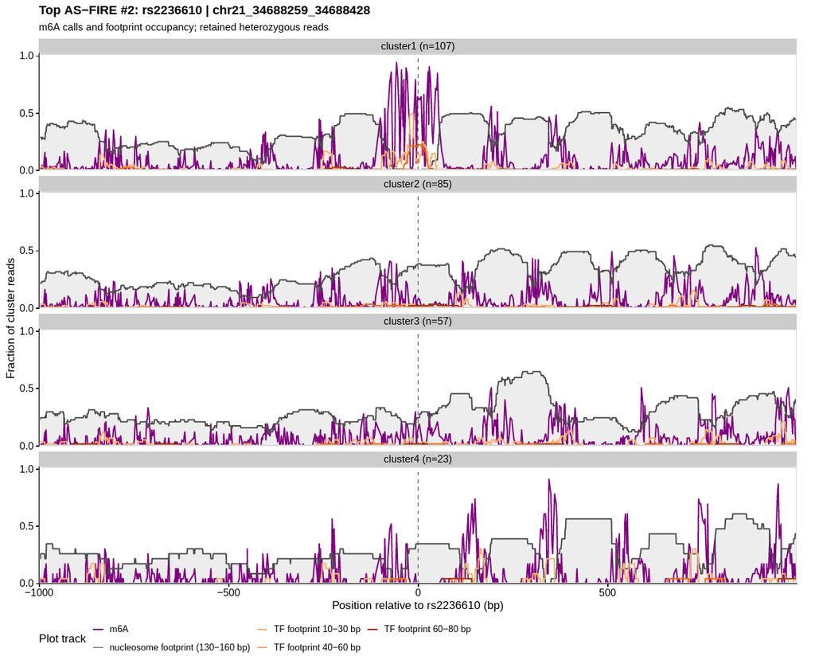

rank02_rs2236610_chr21_34688259_34688428 — Occupancy profiles by cluster

Download original PDF: fig2_occupancy_by_cluster

### rank03_rs4061832_chr3_98334086_98334294

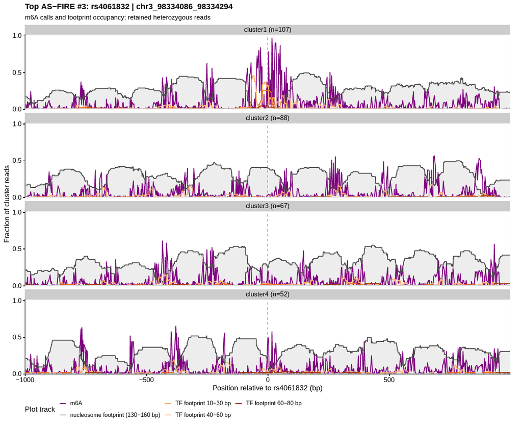

rank03_rs4061832_chr3_98334086_98334294 — Occupancy profiles by cluster

Download original PDF: fig2_occupancy_by_cluster

### rank04_rs170738_chr5_55421001_55421578

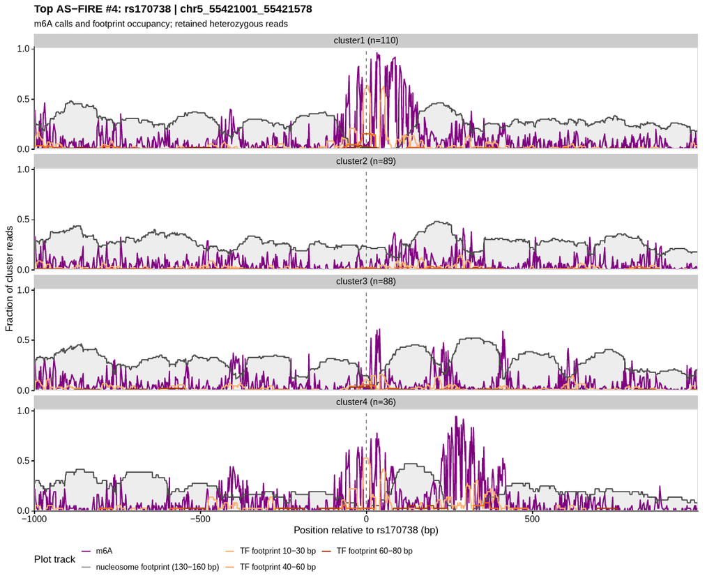

rank04_rs170738_chr5_55421001_55421578 — Occupancy profiles by cluster

Download original PDF: fig2_occupancy_by_cluster

### rank05_rs1457288_chr8_109521517_109521780

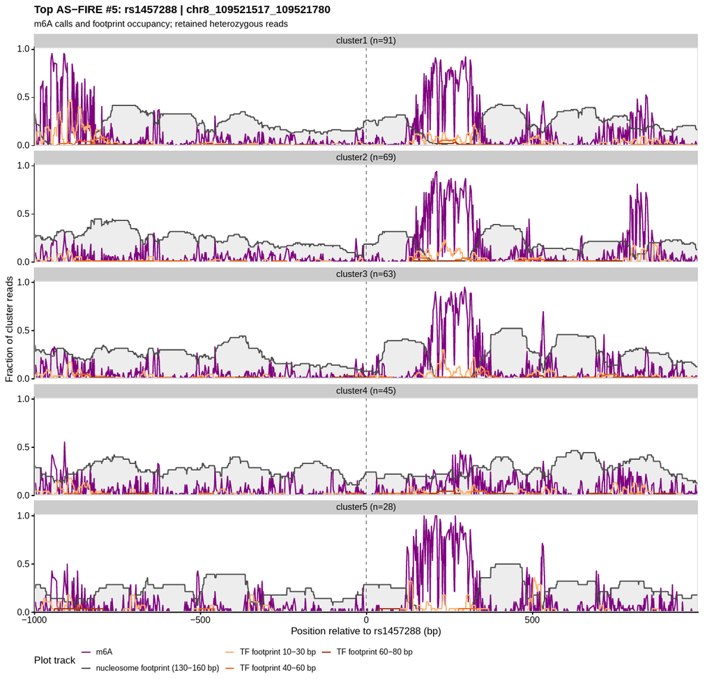

rank05_rs1457288_chr8_109521517_109521780 — Occupancy profiles by cluster

Download original PDF: fig2_occupancy_by_cluster

### rank06_rs10826861_chr10_30751957_30752154

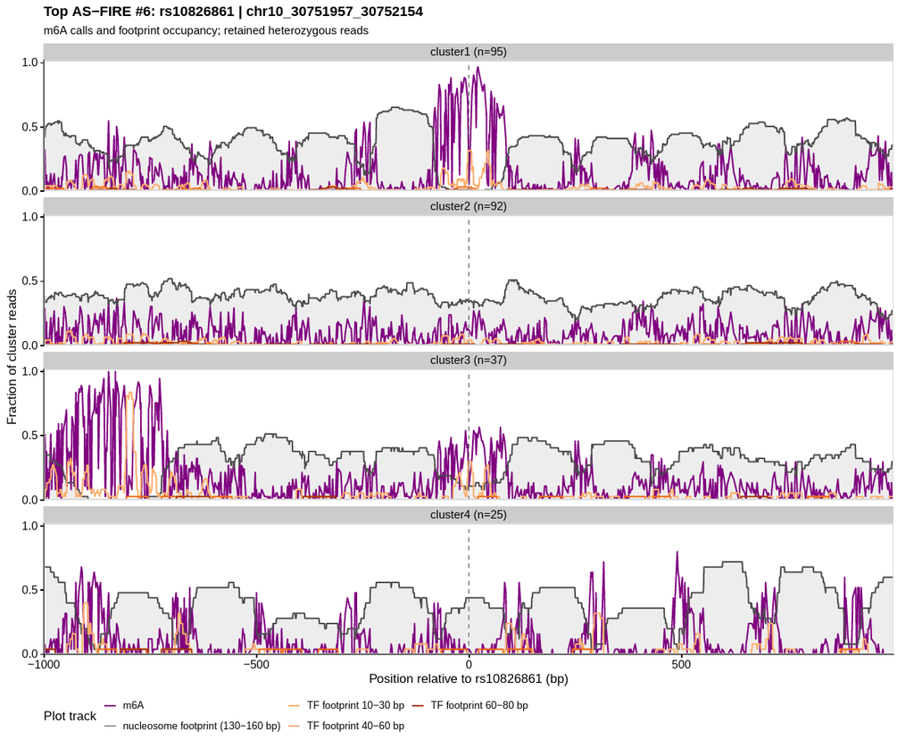

rank06_rs10826861_chr10_30751957_30752154 — Occupancy profiles by cluster

Download original PDF: fig2_occupancy_by_cluster

### rank07_rs1999686_chr9_31146879_31147088

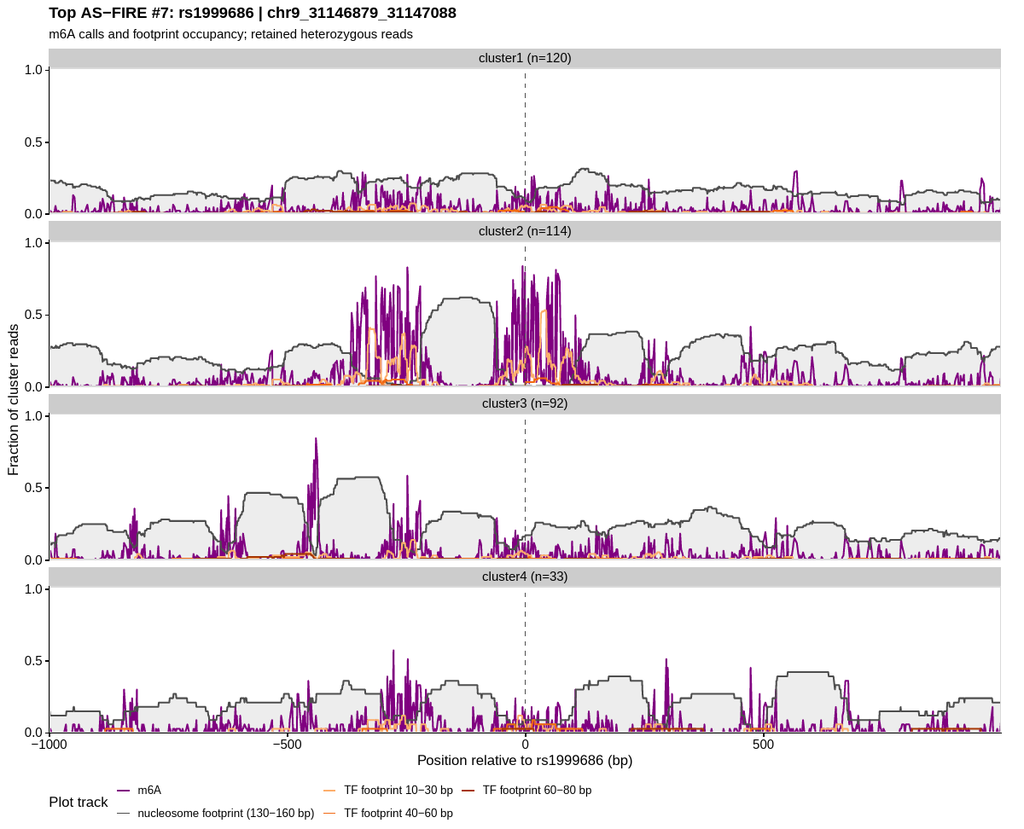

rank07_rs1999686_chr9_31146879_31147088 — Occupancy profiles by cluster

Download original PDF: fig2_occupancy_by_cluster

### rank08_rs12666349_chr7_31688407_31688773

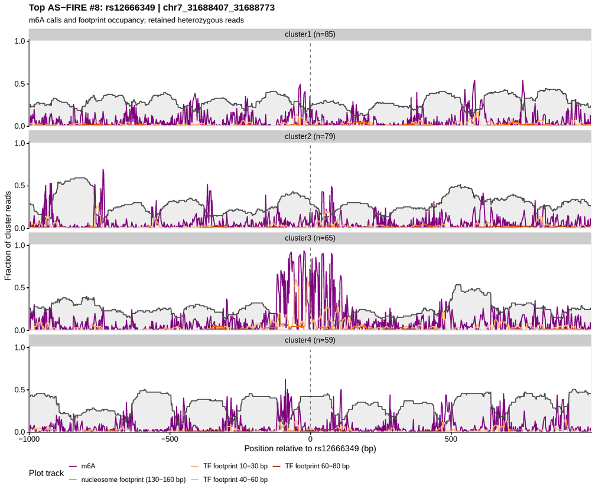

rank08_rs12666349_chr7_31688407_31688773 — Occupancy profiles by cluster

Download original PDF: fig2_occupancy_by_cluster

### rank09_rs17306827_chr2_173899075_173899320

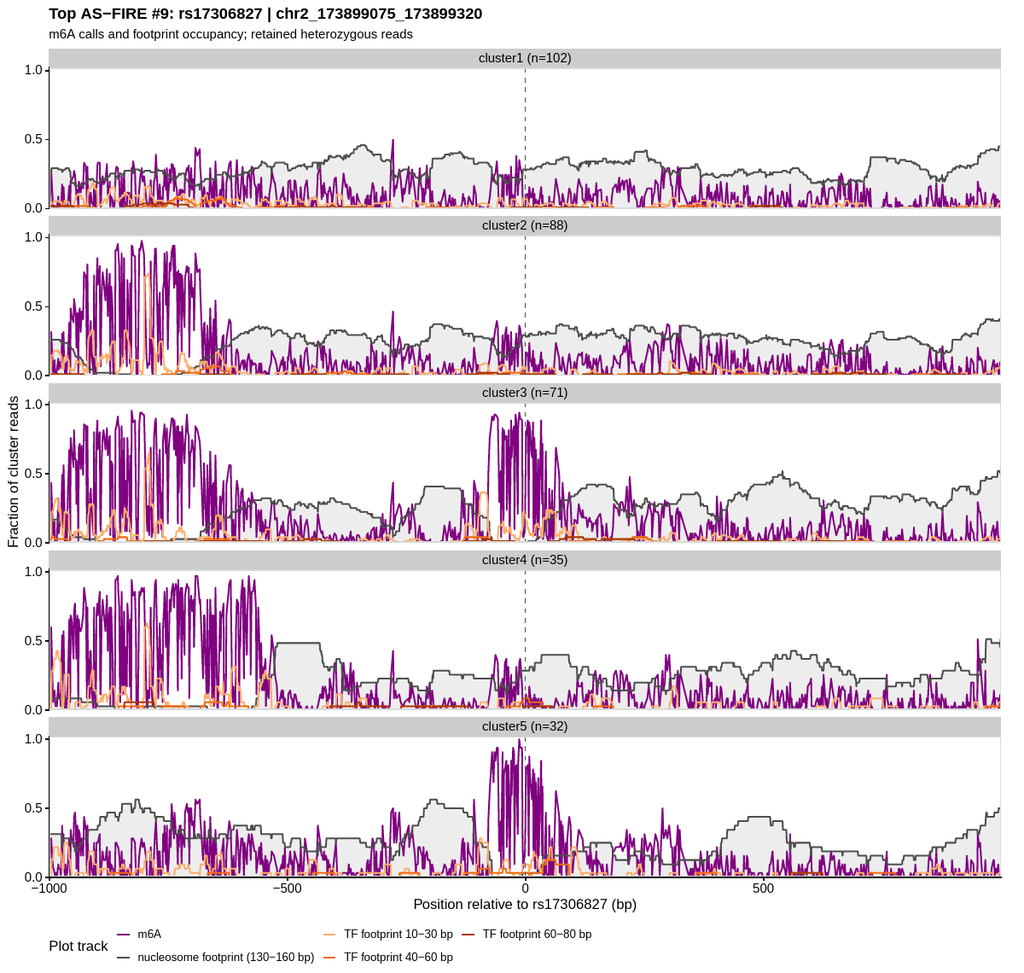

rank09_rs17306827_chr2_173899075_173899320 — Occupancy profiles by cluster

Download original PDF: fig2_occupancy_by_cluster

### rank10_rs2210798_chr6_8481830_8482016

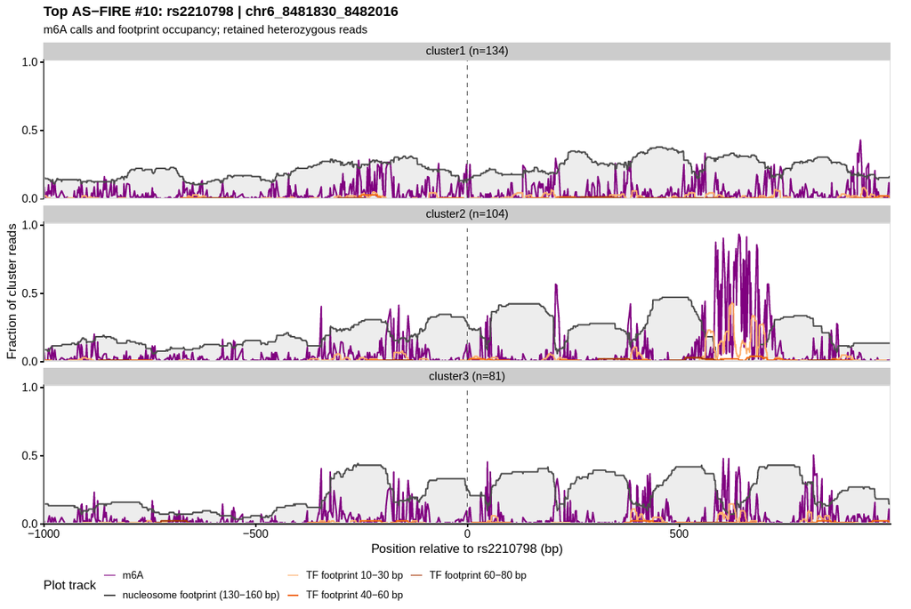

rank10_rs2210798_chr6_8481830_8482016 — Occupancy profiles by cluster

Download original PDF: fig2_occupancy_by_cluster

```r
figure_gallery("heatmap_m6a_footprints", "m6A and footprint heatmaps")
```

## m6A and footprint heatmaps

### rank01_rs12470189_chr2_119290945_119291178

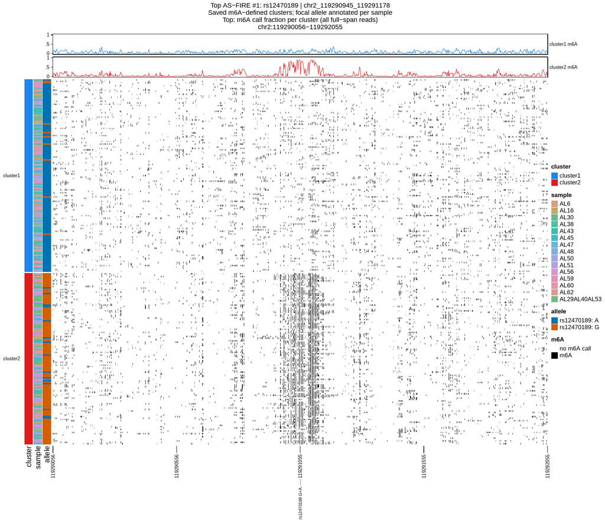

rank01_rs12470189_chr2_119290945_119291178 — m6A and footprint heatmaps

Download original PDF: heatmap_m6a_footprints

### rank02_rs2236610_chr21_34688259_34688428

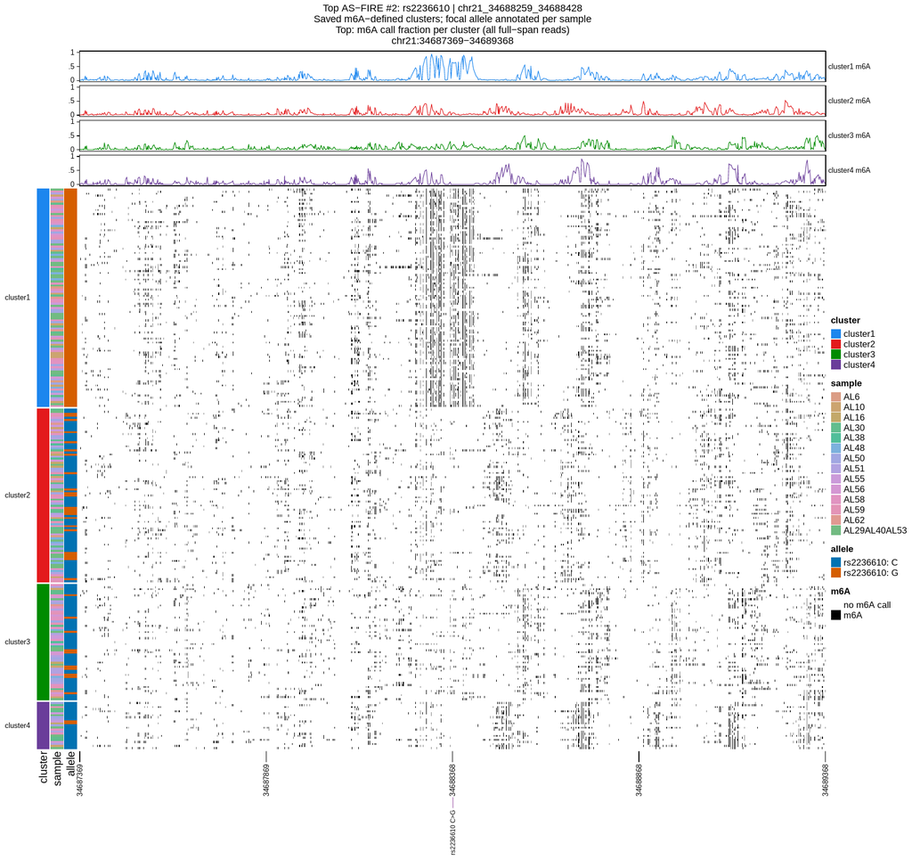

rank02_rs2236610_chr21_34688259_34688428 — m6A and footprint heatmaps

Download original PDF: heatmap_m6a_footprints